# 05 Workshop Mixed-effects models

Xanthe Walker

2025-08-05

### Key Points

#### Fixed vs. random effects

- Fixed and random effects affect mean and variance of y, respectively.
- Examples

  ```
    Fixed: Nutrient added or not, male or female, upland or lowland, wet versus dry, light versus shade, one age versus another

    Random: genotype, block within a field, individuals with repeated measures, family, parent
  ```

- Mixed-effects models maximize use of info in the data, compared to 2-stage analysis.

#### Linear mixed-effects models

- Random intercept model
- Random intercept and slope model
- Random effects model

#### Model selection and validation

- Step 1: fit linear regression
- Step 2: fit model with gls (so linear regression model can be compared with mixed-effects models)
- Step 3: choose variance structure
  - Introduce random effects, and/or
  - Adjust variance structure to take care of heterogeneity
- Step 4: fit the model
  - Make sure `method="REML"`

    `M1.lme=lme(Form, random=~1|Nest, method="REML", data=Owls)`
- Step 5: compare new mixed-effects model with old

  `Form <- formula(LogNeg~SexParent*FoodTreatment+SexParent*ArrivalTime)`

  `M.gls = gls(Form, data=Owls)`

  `M1.lme=lme(Form, random=~1|Nest, method="REML", data=Owls)`

  `anova(M.gls, M1.lme)`
- Stept 6: validate model and, if necessary, repeat steps 4 and 5 until good model is found
- Steps 7 and 8: find optimal fixed effects structure

  First, interaction terms; drop one at time and compare models

  Use `methods="ML"`
- Step 9: refit with REML and validate model
- Step 10: interpret

### Analysis Example

The data:

Data was collected for 3 different fish species (S1-3) with 10 individuals sampled per species across 6 different lakes (L1-6). Individuals from each species were measured and exhibit variation in their body length and trophic position.

```r
#read in the data
fish.data <- read.csv(file="../../Data files/fishdata.csv")
```

The underlying question for these data is: does fish trophic position increase with fish size? This relationship might differ slightly among species due to unmeasured biological processes (e.g. growth rate) or among lakes due to unmeasured environmental variables. But we are not interested in this variation, so we need to find a way to control these potential effects while still maximizing the use of our data.

Thus, a mixed effects model for nested data is applicable in this case! All analyses are done using the package `{nlme}` but can also be done in `{lme4}`

```r
library(nlme)
```

In linear mixed models, intercepts and/or slopes are allowed to vary according to a given factor (random effect; e.g. by lake and/or species).

Allowing intercepts and/or slopes to vary by random effects means that you assume they come from a normal distribution. A mean and standard deviation of that distribution are estimated based on your data. The most likely intercepts and slopes from that distribution are then fit by optimization (ex. maximum likelihood or restricted maximum likelihood).

#### Check the data structure

```r
# Look at data structure
str(fish.data)
```

```
## 'data.frame':    180 obs. of  4 variables:
##  $ Lake        : chr  "L1" "L1" "L1" "L1" ...
##  $ Fish_Species: chr  "S1" "S1" "S1" "S1" ...
##  $ Fish_Length : num  105 195 294 414 237 ...
##  $ Trophic_Pos : num  2.6 2.7 2.74 2.74 2.79 ...
```

```r
# Look at the distribution of samples for each factor
table(fish.data[ , c("Lake", "Fish_Species")])
```

```
##     Fish_Species
## Lake S1 S2 S3
##   L1 10 10 10
##   L2 10 10 10
##   L3 10 10 10
##   L4 10 10 10
##   L5 10 10 10
##   L6 10 10 10
```

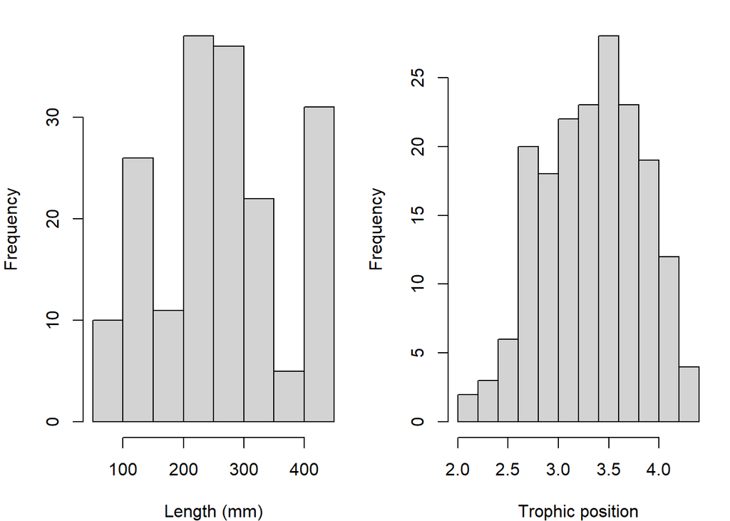

```r
# Look at the distribution of continuous variables:
par(mfrow = c(1, 2), mar = c(4, 4, 1, 1))
hist(fish.data$Fish_Length, xlab = "Length (mm)", main = "")
hist(fish.data$Trophic_Pos, xlab = "Trophic position", main = "")
```

Major deviations could cause heteroscedasticity problems. If necessary, make transformations. In this case, the data seems OK.

#### Check collinearity

The problem with collinear predictors is simply that they explain the same thing, so their effect on the response variable will be confounded in the model.

In this example, there is no risk of collinearity with only one continuous variable. If you had another continuous variable (var2), one simple way to check for collinearity is cor(var1, var2)

#### Consider scale

If two variables in the same model have very different scales, the mixed model will likely return a convergence error when trying to compute the parameters. The Z-correction standardizes the variables and solve this problem.

Body scale = long scale Trophic position = short scale

Because our data have very different scales of variation, we apply the Z-correction

```r
# Standardized length, "by hand"
fish.data$Z_Length <- (fish.data$Fish_Length - mean(fish.data$Fish_Length)) /
                      sd(fish.data$Fish_Length)

# Standardized trophic position, with the function scale
fish.data$Z_TP <- scale(fish.data$Trophic_Pos)
```

Interpreting scaled variables When a variable is scaled (standardized), a one-unit increase in the scaled version corresponds to a one standard deviation increase in the original variable. This makes model coefficients easier to interpret, especially when units differ dramatically.

#### Step 1: Linear Regression

```r
## Create a linear model without random effects
lm.test <- lm(Z_TP ~ Z_Length, data = fish.data)
summary(lm.test)
```

```
##
## Call:
## lm(formula = Z_TP ~ Z_Length, data = fish.data)
##
## Residuals:
##     Min      1Q  Median      3Q     Max
## -2.2703 -0.7060  0.2144  0.6432  1.6157
##
## Coefficients:
##              Estimate Std. Error t value Pr(>|t|)
## (Intercept) 9.686e-17  6.761e-02   0.000        1
## Z_Length    4.263e-01  6.780e-02   6.287 2.43e-09 ***
## ---
## Signif. codes:  0 '***' 0.001 '**' 0.01 '*' 0.05 '.' 0.1 ' ' 1
##
## Residual standard error: 0.9071 on 178 degrees of freedom
## Multiple R-squared:  0.1817, Adjusted R-squared:  0.1771
## F-statistic: 39.52 on 1 and 178 DF,  p-value: 2.432e-09
```

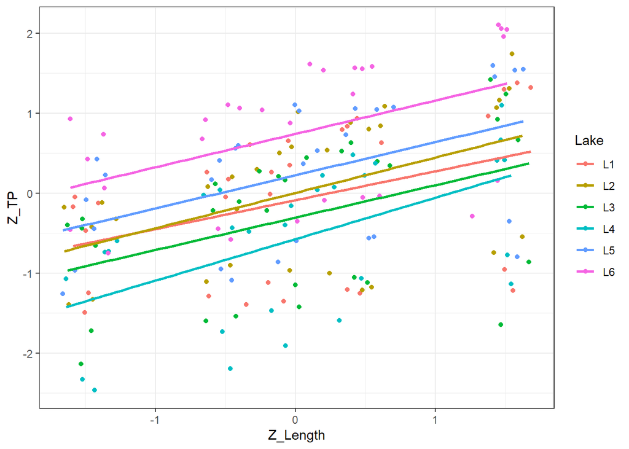

```r
## plot the data with ggplot

prelim_plot <- ggplot(fish.data, aes(x = Z_Length, y = Z_TP, color=Lake)) +
  geom_point() + theme_bw()+
  geom_smooth(method = "lm", se=FALSE)
prelim_plot
```

```r
## Calculate residuals of this linear model
lm.test.resid <- rstandard(lm.test)
```

#### Step 2: Fit the Model with GLS

In this step we fit the model using the gls function. It allows us to compare the linear regression model with the mixed effects model that we will calculate using the lme function in a moment.

```r
M.gls <- gls(Z_TP ~ Z_Length, data = fish.data)
```

The output is identical to that from lm function.

#### Step 3: Choose a Variance Structure

Last week we talked about the optimal variance structure in terms of heterogeneity. We can still do that here, but adding the random component is our first priority. Note that the random intercept is also part of the ‘choose a variance structure’ process.

We should choose our random structure based on knowledge of the study design but can also look at residual plots of the linear model to assess if there is potential variance associated with our proposed random effects.

Remember we want to determine if the trophic position can be predicted by body length, while taking into account the variation between species and lakes.

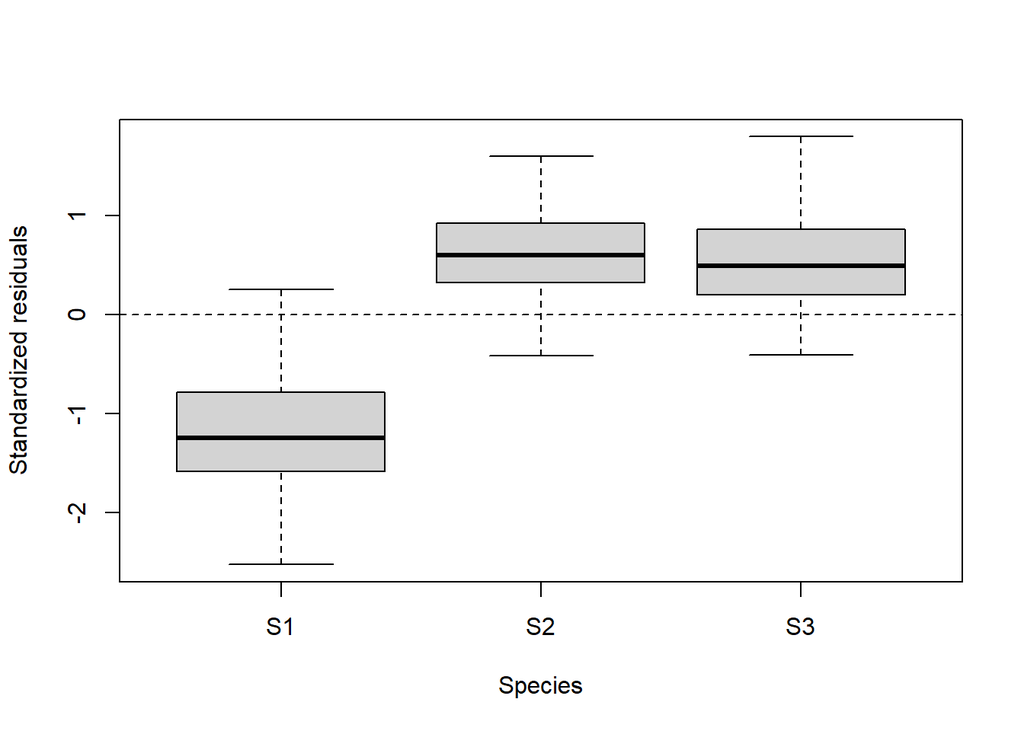

```
## integer(0)
```

```r
##Plot the residuals against the levels of the potential random factors
plot(lm.test.resid ~ as.factor(fish.data$Fish_Species),
     xlab = "Species", ylab = "Standardized residuals")+ abline(0, 0, lty = 2)
```

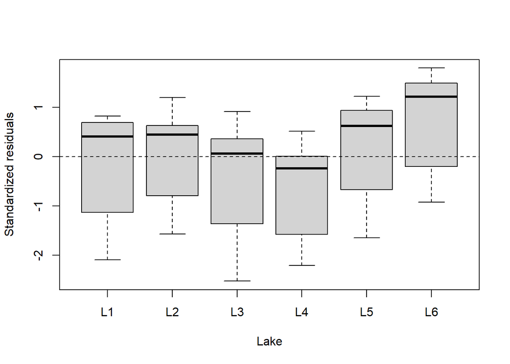

```
## integer(0)
```

```r
plot(lm.test.resid ~ as.factor(fish.data$Lake),
     xlab = "Lake", ylab = "Standardized residuals") + abline(0, 0, lty = 2)
```

These results suggest that there is residual variance that could be explained by these factors, so they should be included in a mixed effect model!

We can account for this by including random intercepts for both lake and species in the model.

#### Step 4: Fit the model

We will ignore the effect of Fish_Species here and only use Lake. Note that this will violate the assumption of independence - but given that there are only 3 fish species it should be included as fixed effect.

```r
library(nlme)
M1.lme= lme(Z_TP ~ Z_Length, random=~1|Lake,
     data = fish.data, method="REML")
```

###### A note on estimation methods

The Maximum Likelihood (ML) method underestimate model variances by a factor of  
(n−k)/n, where k is the number of fixed effects. The REML method corrects for this bias.

REML estimates can be used when comparing models with the same fixed effects (i.e. nested models). However, if you are comparing models where the fixed effects differ among models then maximum likelihood should be used to fit parameters as this method is not dependent on the coefficients of the fixed effects. Fitting using maximum likelihood is done by setting REML=FALSE in the lmer command.

In summary: * REML to compare models with nested random effects and the same fixed effect structure * ML to compare models with nested fixed effects and the same random effect structure * ML to compare models with and without random effects

Using lme vs lmer In this workshop, we’ve used the {nlme} package and the lme() function to fit mixed models. This package is great for model comparisons and for specifying correlation and variance structures.

However, in the exercises, we will also use {lme4} and its function lmer():

```r
library(lme4)
M1.lmer <- lmer(Z_TP ~ Z_Length + (1 | Lake), data = fish.data)
summary(M1.lmer)
```

```
## Linear mixed model fit by REML ['lmerMod']
## Formula: Z_TP ~ Z_Length + (1 | Lake)
##    Data: fish.data
##
## REML criterion at convergence: 454.8
##
## Scaled residuals:
##     Min      1Q  Median      3Q     Max
## -2.4428 -1.0671  0.4550  0.7882  1.3434
##
## Random effects:
##  Groups   Name        Variance Std.Dev.
##  Lake     (Intercept) 0.1839   0.4289
##  Residual             0.6679   0.8173
## Number of obs: 180, groups:  Lake, 6
##
## Fixed effects:
##              Estimate Std. Error t value
## (Intercept) 9.370e-17  1.854e-01   0.000
## Z_Length    4.253e-01  6.109e-02   6.961
##
## Correlation of Fixed Effects:
##          (Intr)
## Z_Length 0.000
```

Both lme() and lmer() fit linear mixed-effects models, but they differ slightly:

lmer() allows for more flexible random effect structures (e.g., random slopes), but does not directly support correlated residual structures or variance weights.

lme() supports correlation structures and weighted variance, which can be useful in ecological data with heteroscedasticity or temporal autocorrelation.

#### Step 5: Compare New Model with Old Model

We use the anova command to compare the models M.gls and M1.lme. Note that the models were estimated with REML, which allows us to apply the likelihood ratio test to see whether we need the random intercept.

```r
anova(M.gls, M1.lme)
```

```
##        Model df      AIC      BIC    logLik   Test L.Ratio p-value
## M.gls      1  3 486.8283 496.3737 -240.4142
## M1.lme     2  4 462.8140 475.5412 -227.4070 1 vs 2 26.0143  <.0001
```

The likelihood ratio test indicates that the model with the random intercept is considerably better. The AIC of the model with the random intercept is also considerably smaller, confirming the results of the likelihood ratio test. As well as the random intercept, it is also an option to use a random intercept and random slope model. Give it a try!

#### Step 6: Everything Ok?

Now that we have our model, we must verify that the model follows all the basic assumptions:

1. Check the homogeneity of the variance:
- Plot predicted values vs residual values
2. Check the independence of the model residuals:
- Plot residuals vs each covariate of the model
- Plot residuals vs each covariate not included in the model
3. Check the normality of the model residuals:
- Histogram of residuals
1. Check the homogeneity of the variance:

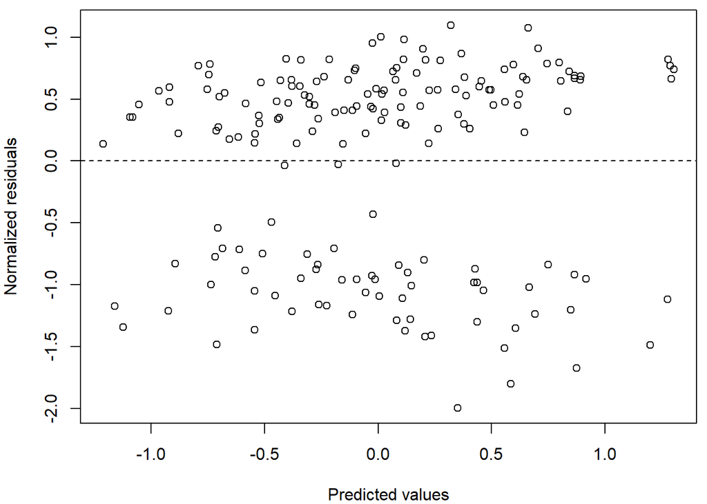

```r
# Plot predicted values vs residual values
par(mar = c(4, 4, 0.5, 0.5))
plot(resid(M1.lme) ~ fitted(M1.lme), xlab = "Predicted values", ylab = "Normalized residuals")
abline(h = 0, lty = 2)
```

2. Check the independence of the model residuals with each covariate

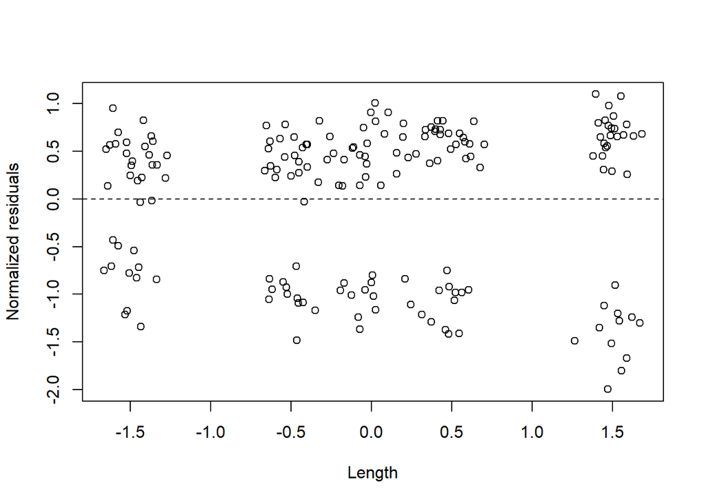

```
## integer(0)
```

```r
# In order to check the independence of the model residuals
# we need to plot residuals vs each covariate of the model


plot(resid(M1.lme) ~ fish.data$Z_Length, xlab = "Length", ylab = "Normalized residuals")+abline(h = 0, lty = 2)
```

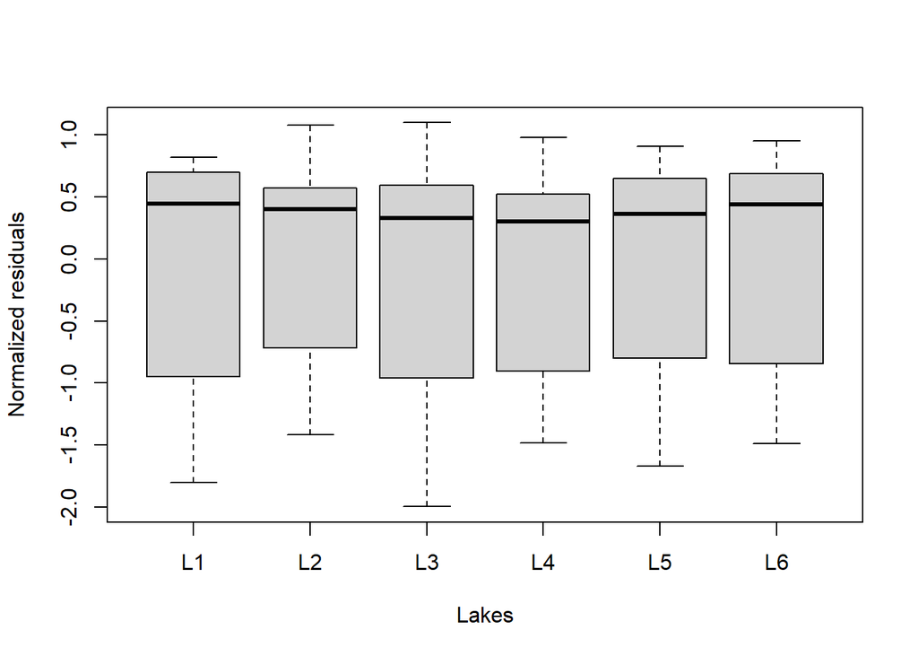

```r
boxplot(resid(M1.lme) ~ Lake, data = fish.data, xlab = "Lakes", ylab = "Normalized residuals")
```

Now, we should (2) plot residuals vs each covariate not included in the model.

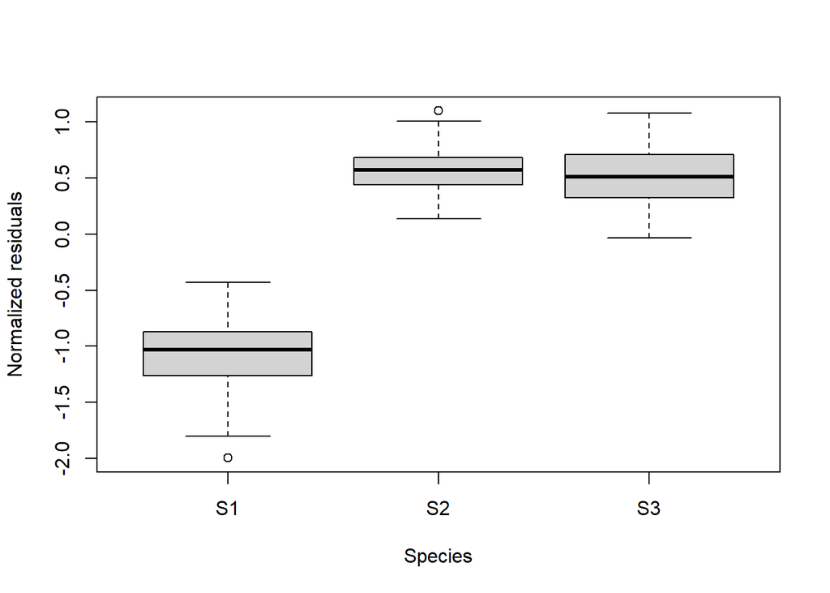

```r
boxplot(resid(M1.lme) ~ Fish_Species, data = fish.data, xlab = "Species",
    ylab = "Normalized residuals")
```

If you observe patterns in these plots (as we do!), you will know that there is variation in your dataset that could be explained by these covariates and you should consider including them in your model. Try adding Fish Species as a Fixed effect and go through each of the steps.

3. Check the normality of the model residuals

Now we will check the normality of the model residuals as residuals following a normal distribution indicate that the model is not biased.

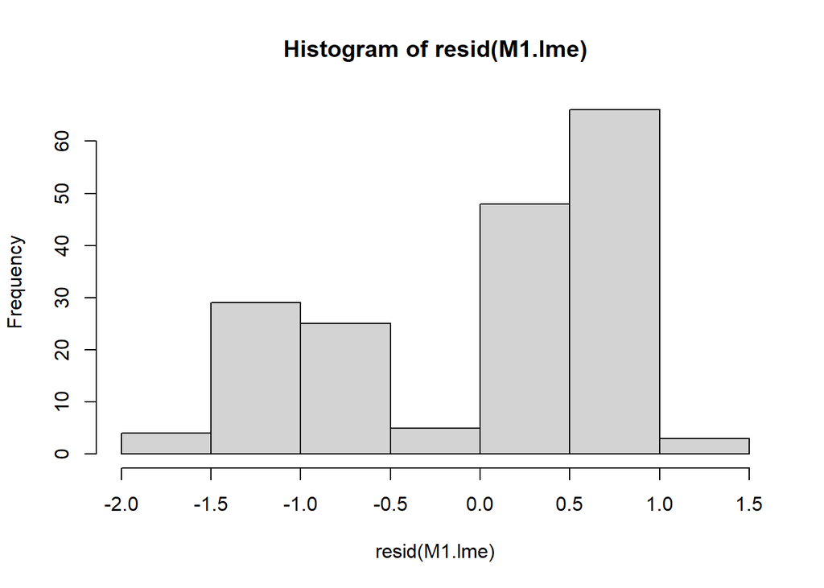

```r
hist(resid(M1.lme))
```

We also need to check that our random effects come from a normal distribution

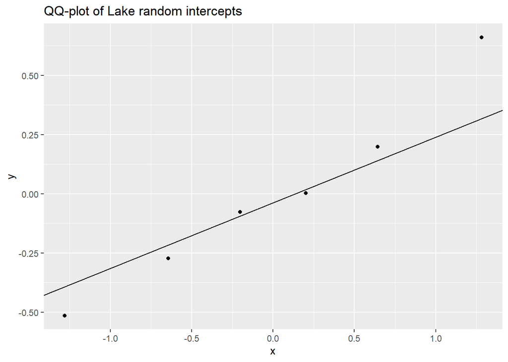

```r
re <- ranef(M1.lmer, condVar = TRUE)
re_df <- as.data.frame(re$Lake)
ggplot(re_df, aes(sample = `(Intercept)`)) +
  stat_qq() + stat_qq_line() +
  labs(title = "QQ-plot of Lake random intercepts")
```

Manually checking residuals is the gold standard for understanding why we diagnose models the way we do. However, the {performance} package also provides a convenient one-function check that summarizes the most important assumption tests and diagnostics in one place.

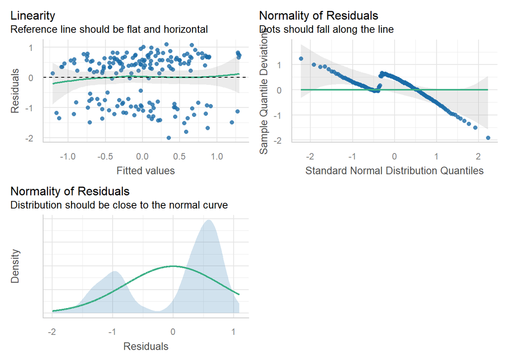

```r
library(performance)
check_model(M1.lme)
```

This produces a set of diagnostic plots and summaries.

Note for this model you will see only three diagnostic panels:

Residuals vs. Fitted (Linearity)

Normal Q-Q Plot (Normality of Residuals)

Histogram/Density Plot of Residuals (Normality of Residuals)

This is expected because some diagnostics are not available for {nlme} model objects or cannot be computed with a single fixed effect.

Why you might see fewer panels in general:

Collinearity checks require more than one fixed effect.

Leverage/influence plots are not available for all {nlme} models.

Singularity checks are only computed for {lme4} models.

**How to read the output (all possible panels):**

1. **Residuals vs. Fitted**  
   Checks for homoscedasticity (equal variance).  
   Points should be evenly scattered around the horizontal line at 0 with no clear pattern.  
   A funnel shape indicates heteroscedasticity; curvature suggests a missing nonlinear term.
2. **Normal Q-Q Plot**  
   Checks whether residuals are approximately normally distributed.  
   Points should follow the diagonal line closely.  
   Heavy tails or strong curvature indicate deviations from normality.
3. **Histogram of Residuals**  
   Another way to assess normality.  
   Look for symmetry around zero; strong skewness may need transformation or reconsideration of model structure.
4. **Leverage and Influence**  
   Identifies observations with high leverage (x-axis) or large influence (y-axis).  
   Points outside the shaded area may disproportionately affect model estimates — investigate these individually.
5. **Collinearity Check**  
   If you have multiple fixed effects, this panel checks variance inflation factors (VIF).  
   VIF > 5 suggests potential multicollinearity issues.
6. **Singularity Check**  
   For random effects: warns if one or more variance components are estimated as zero (possible overfitting).  
   If flagged, consider simplifying your random effects structure. When fitting complex random effect structures with lmer(), you may see a warning that the model is “singular”. This means that one or more variance components (e.g., random slopes) are estimated as essentially zero.

You can also check for singularity using this:

```r
isSingular(M1.lmer)
```

```
## [1] FALSE
```

If TRUE, your model may be overfit — consider simplifying by removing one of the random effects.

#### Steps 7 and 8: The Optimal Fixed Structure

In this step, we look at the optimal model in terms of the explanatory variables. The first thing we should do is to type summary(M1.lme) and inspect the significance of the regression parameters.

Note that you should not use the anova (M1.lme) command as it applies sequential testing (which depends on the order of the two-way interaction terms).

```r
summary(M1.lme)
```

```
## Linear mixed-effects model fit by REML
##   Data: fish.data
##       AIC      BIC   logLik
##   462.814 475.5412 -227.407
##
## Random effects:
##  Formula: ~1 | Lake
##         (Intercept)  Residual
## StdDev:   0.4288529 0.8172672
##
## Fixed effects:  Z_TP ~ Z_Length
##                 Value  Std.Error  DF t-value p-value
## (Intercept) 0.0000000 0.18537305 173 0.00000       1
## Z_Length    0.4253005 0.06109455 173 6.96135       0
##  Correlation:
##          (Intr)
## Z_Length 0
##
## Standardized Within-Group Residuals:
##        Min         Q1        Med         Q3        Max
## -2.4427716 -1.0670604  0.4550309  0.7881865  1.3433701
##
## Number of Observations: 180
## Number of Groups: 6
```

To determine the optimal fixed structure we should use the likelihood ratio test. We need to fit the same model again, but now with ML.

```r
M1.lme= lme(Z_TP ~ Z_Length, random=~1|Lake,
     data = fish.data, method="ML")

M2.lme= lme(Z_TP ~ 1, random=~1|Lake,
     data = fish.data, method="ML")

anova(M1.lme, M2.lme)
```

```
##        Model df      AIC      BIC    logLik   Test  L.Ratio p-value
## M1.lme     1  4 457.4315 470.2034 -224.7158
## M2.lme     2  3 498.4127 507.9916 -246.2063 1 vs 2 42.98115  <.0001
```

You can see that Fish Length is significant at the 5% level. If your model had interactions you would start by dropping the interaction and comparing the full to the reduced.

#### Step 9: Refit with REML and Validate the Model

```r
M1.lme= lme(Z_TP ~ Z_Length, random=~1|Lake,
     data = fish.data, method="REML")
summary(M1.lme)
```

```
## Linear mixed-effects model fit by REML
##   Data: fish.data
##       AIC      BIC   logLik
##   462.814 475.5412 -227.407
##
## Random effects:
##  Formula: ~1 | Lake
##         (Intercept)  Residual
## StdDev:   0.4288529 0.8172672
##
## Fixed effects:  Z_TP ~ Z_Length
##                 Value  Std.Error  DF t-value p-value
## (Intercept) 0.0000000 0.18537305 173 0.00000       1
## Z_Length    0.4253005 0.06109455 173 6.96135       0
##  Correlation:
##          (Intr)
## Z_Length 0
##
## Standardized Within-Group Residuals:
##        Min         Q1        Med         Q3        Max
## -2.4427716 -1.0670604  0.4550309  0.7881865  1.3433701
##
## Number of Observations: 180
## Number of Groups: 6
```

Let’s go section by section and try to understand what we are looking at.

The output is broken up into descriptions of the Random effects (things we allow to vary based on the normal distribution) and Fixed effects (things we estimate in the same way as classical regression):

Random effects: Groups: grouping factors

Name: (Intercept) for the intercepts or the name of the variable on which the random slope is estimated (Z_length in this example)

Std.Dev. is the standard deviation of the estimated effect. The variance of the effect is St.Dev^2. We can use this to calculate the Intraclass Correlation Coefficient (ICC). The ICC is calculated as the ratio of variance between the random effect and the total variance. Thus, the ICC describes the proportion of variance in the response variable that is attributed to a specific random effect Variance = St.Dev^2 ICC = (Variance of the Effect)/(Variance of the Effect + Residual Variance)

In this case, ICC = (0.4288<sup>2)/(0.4288</sup>2 + 0.8172672^2) = 0.2158611 So the difference between lakes explains ~20% of the varaince that is “left over” after the variance explained by our fixed effects.

Corr the correlation between the random intercept and the random slope for a given grouping factor.

Fixed effects: This part presents the fixed effect estimates.

These statistics could be used as it is (although be careful of interpreting the p-value). You could also calculate the 95% confidence interval (CI) with this equation:

CI = Estimate +- 1.96 *Std. Error

If 0 is in the interval, then the parameter is not significantly different from zero at a threshold of α = 0.05.

#### Step #10 - Interpret - and plot results

```r
# ggplot theme

fig <- theme_bw() + theme(panel.grid.minor = element_blank(),
    panel.grid.major = element_blank(), panel.background = element_blank()) +
    theme(strip.background = element_blank(), strip.text.y = element_text()) +
    theme(legend.background = element_blank()) + theme(legend.key = element_blank()) +
    theme(panel.border = element_rect(colour = "black", fill = NA))

library(ggeffects)  # install the package first if you haven't already, then load it

# Extract the prediction data frame
pred.mm <- ggpredict(M1.lme, terms = c("Z_Length"))  # this gives overall predictions for the model
head(pred.mm)
```

```
## # Predicted values of Z_TP
##
## Z_Length | Predicted |       95% CI
## -----------------------------------
##    -2.00 |     -0.85 | -1.29, -0.41
##    -1.50 |     -0.64 | -1.05, -0.23
##    -1.00 |     -0.43 | -0.81, -0.04
##    -0.50 |     -0.21 | -0.58,  0.16
##     0.00 |      0.00 | -0.37,  0.37
##     0.50 |      0.21 | -0.16,  0.58
##
## Adjusted for:
## * Lake = 0 (population-level)
```

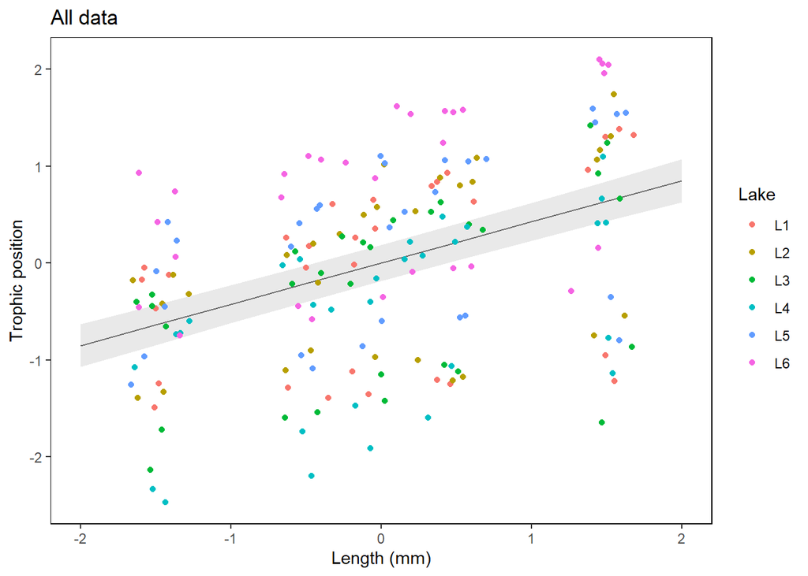

```r
# Plot the predictions

ggplot(pred.mm) +
   geom_line(aes(x = x, y = predicted)) +          # slope
   geom_ribbon(aes(x = x, ymin = predicted - std.error, ymax = predicted + std.error),
               fill = "lightgrey", alpha = 0.5) +  # error band
   geom_point(data = fish.data,                      # adding the raw data (scaled values)
              aes(x = Z_Length, y = Z_TP, colour = Lake)) +
   labs(x = "Length (mm)", y = "Trophic position",
        title = "All data") +
   fig
```

#### Optional - R2 statistics

```r
library(MuMIn)
r.squaredGLMM(M1.lme)
```

```
##            R2m       R2c
## [1,] 0.1751494 0.3532371
```

The r.squaredGLMM() function from the {MuMIn} package provides two types of R-squared values for mixed-effects models:

Marginal R² (R2m): the proportion of variance explained by the fixed effects alone.

Conditional R² (R2c): the proportion of variance explained by both fixed and random effects combined.

In this case:

R2m = 0.175: About 17.5% of the variation in trophic position is explained by fish length (the fixed effect).

R2c = 0.353: About 35.3% of the variation is explained when we account for both fish length and variation among lakes (the random effect).

This tells us that lake-level differences explain a substantial portion of the remaining variation — nearly doubling the explanatory power of the model when included.

### Random Intercept and Slope Model

In the main analysis, we accounted for variation among lakes by allowing intercepts to vary (i.e., different mean trophic positions per lake). Now we’ll explore whether the relationship between body length and trophic position (the slope) also differs by lake. This can be done by fitting a random slope model.

#### Fit the model with a random intercept and random slope

```r
M.randslope <- lme(Z_TP ~ Z_Length,
                   random = ~ Z_Length | Lake,
                   data = fish.data,
                   method = "REML")
```

Including (Z_Length | Lake) means each lake has its own intercept and its own slope for the Z_Length–Z_TP relationship. You are allowing the slope of the relationship between fish length and trophic position to vary by lake. This is useful when different groups might not only start at different intercepts, but also have different relationships between predictors and the response.

#### Compare with random intercept-only model

To determine whether the more complex model improves fit, we compare it to the random intercept-only model using a likelihood ratio test.

```r
anova(M1.lme, M.randslope)
```

```
##             Model df     AIC      BIC   logLik   Test      L.Ratio p-value
## M1.lme          1  4 462.814 475.5412 -227.407
## M.randslope     2  6 466.814 485.9047 -227.407 1 vs 2 6.540267e-08       1
```

If the model with random slopes has a lower AIC and the LRT p-value is small (e.g., < 0.05), this suggests that lakes differ not only in their average trophic position but also in how body size affects trophic position. That is not the case here. And we would not use this model over the random intercept model.

### Appendix: Common mixed model syntax

Below is a reference for common tasks when working with linear mixed-effects models:

**Random intercept model**  
lmer(y ~ x + (1 | group), data = dat)

**Random intercept and random slope model**  
lmer(y ~ x + (x | group), data = dat)

**Compare two models**  
anova(model1, model2)

**Extract R² values (marginal and conditional)**  
library(MuMIn) r.squaredGLMM(model)

**Check model assumptions visually**  
check_model(model)

**Extract fixed effects**  
fixef(model)

**Extract random effects**  
ranef(model)

## Exercises

To apply what you’ve learned about mixed-effects models, use the following exercises to explore real ecological datasets. Each one walks through model fitting, diagnostics, and interpretation using scenarios relevant to ecology.

### Start Here: Core Exercises

Start with these two exercises to build confidence with the most important concepts:

1. **Exercise 1: Bear Movement and Heart Rate**  
   Explore how seasonal movement influences heart rate in black bears, accounting for repeated measures within individual bear-years.
2. **Exercise 2: Canopy Nitrogen Allocation**  
   Analyze how nitrogen concentration varies with height and species, and test whether the slope of that relationship differs among individuals.

These two exercises emphasize: - Fitting and interpreting linear mixed-effects models  
- Comparing models with random intercepts and random slopes  
- Checking model assumptions and evaluating diagnostics  
- Interpreting biologically meaningful fixed-effect interactions

### Optional: Additional Practice

If you’d like more practice or want to work with longitudinal or more complex hierarchical datasets, try one or both of the following:

- **Exercise 3: Telomere Length in Aging Birds**  
  Model how telomere length declines with age in infected vs. uninfected birds, allowing individual aging trajectories to vary.
- **Exercise 4: Telomeres and Parental Infection**  
  Explore how maternal infection and age influence early-life telomere length in offspring, using models with two levels of random effects.

These exercises are particularly useful if you’re working with: - Repeated measures across time (longitudinal data)  
- Interaction terms involving continuous predictors  
- Nested or crossed random effects in ecological studies

## Exercise 1: Bear Movement and Heart Rate

This dataset includes GPS and heart rate data from black bears tracked across multiple years. Each record represents one “bear-year” (a unique individual in a specific year). You’ll explore how movement and season influence heart rate while accounting for repeated observations within bear-year.

1. **Read in the dataset** `bearmove.csv`.  
   Create a centered and scaled version of `log.move` called `log.move.sc`.
2. **Visualize** the relationship between `log.move.sc` and `log(hr)`, colored by `Season` and faceted by `BearIDYear`.
3. **Fit a linear model** using `lm()` that ignores repeated measures. Include `log.move.sc`, `Season`, and their interaction as fixed effects.  
   > *Interpret the coefficients.*
4. **Fit a random intercept model** using `lmer()` with `BearIDYear` as a random intercept.  
   > *What does this model account for? Does it improve model fit compared to the linear model?*
5. **Fit a random coefficients model** that includes random slopes and intercepts for `log.move.sc * Season` by `BearIDYear`.  
   > *Does this model improve fit? Is it overparameterized or singular?*
6. **Compare the random intercept and random slope models** using a likelihood ratio test or AIC.  
   > *Which model performs better and why?*
7. **Propose a simpler alternative** to the maximal random slopes model.  
   > *What structure might better account for the data without overfitting?*

## Exercise 2: Canopy Nitrogen Allocation

This dataset includes leaf nitrogen concentration (`narea`) and vertical canopy position (`dfromtop`) for leaves on 35 trees of two species.

1. **Read in the dataset** `prefdata.csv`.
2. **Visualize** the relationship between `narea` and `dfromtop`, colored by species.
3. **Fit a mixed-effects model** with:
   - Fixed effects: `species`, `dfromtop`, and their interaction
   - Random intercept: `ID` (individual tree)
4. **Fit a model with a random slope** for `dfromtop` by `ID`.  
   > *Does this improve model fit?*
5. **Assess the significance** of the interaction between `species` and `dfromtop`.  
   > *Use either `car::Anova()` or compare a model with and without the interaction.*
6. **Check model assumptions** using `check_model()`.  
   > *Do residuals look homoscedastic and normal?*
7. **Interpret the fixed effect coefficients** from the summary output.  
   > *What do they tell you about nitrogen allocation across species and canopy height?*
8. **Use `emmeans::emtrends()`** to extract and compare slopes of `dfromtop` by species.  
   > *Are they significantly different?*
9. **Visualize the final model predictions** using one of the following:
   - `visreg()`
   - `ggeffects::ggpredict()`
   - Custom `ggplot2` with ribbons and predicted lines

## Exercise 3: Telomere Length in Aging Birds

This dataset (`birdmalariaTL.csv`) includes telomere length data for birds of varying ages, some of which are chronically infected with malaria. You’ll test whether infection accelerates aging (via telomere shortening), while accounting for repeated observations within individuals.

1. **Read in the dataset** `birdmalariaTL.csv`.
2. **Fit a random intercept model** with:
   - Response: `TL` (telomere length)
   - Predictors: `Sex`, `year`, `Age`, `infected`, and `Age * infected`
   - Random intercept: `Ind` (individual bird)  
     > *What does the coefficient for `Age:infected` tell you about aging in infected birds?*
3. **Fit a random intercept and slope model** allowing the slope of `Age` to vary by `Ind`.  
   > *Why is this more appropriate when `Age` varies within individual?*
4. **Compare the models** in terms of:
   - Coefficient estimates for `Age` and `Age:infected`
   - Confidence intervals  
     > *What changes do you see in the estimates and their uncertainty?*
5. **Use AIC or likelihood ratio tests** to compare model fit.  
   > *Which model would you choose and why?*
6. **Check model assumptions** using `check_model()`.  
   > *Are residuals and random effects approximately normal? Any signs of heteroscedasticity or outliers?*
7. **Predict telomere length** for an infected female born in 1991, age 4, using `predict()` or matrix multiplication.  
   > *How would you explain this prediction to a non-statistical audience?*

## Exercise 4: Telomeres and Parental Infection

In this dataset (`birdmalaria0.csv`), you’ll model early-life telomere length in offspring birds in relation to maternal age and malaria infection status, accounting for family structure.

1. **Read in the dataset** `birdmalaria0.csv`.
2. **Fit a mixed-effects model** with:
   - Response: `OffBTL` (offspring telomere length at day 9)
   - Fixed effects: `Sex`, `broodyear`, `mage`, `mmal`, and `mage:mmal`
   - Random effects: `dam` (mother ID) and `brood` (brood ID)
3. **Check model assumptions** using `check_model()`.  
   > *Comment on normality of residuals, residual vs. fitted patterns, and any heteroscedasticity.*
4. **Evaluate the significance of the interaction** `mage:mmal` using a likelihood ratio test.  
   > *What does this interaction mean biologically?*
5. **Visualize model predictions** using:
   - `ggpredict()`
   - Or custom `ggplot2` visualizations with fitted lines and ribbons  
     > *What do the plots suggest about the effects of maternal age and infection on offspring telomere length?*